# Chapter 4: Part 1

## Example 4.1: Computer Response Time

The response time of a distributed computer system is an important quality characteristic. The system manager wants to know whether the mean response time to a specific type of command exceeds 75 millisec. From previous experience, he knows that the standard deviation of response time is 8 millisec.

Here’s how to do it in R.

```r
#first define the variables
x_bar = 79.25
sample_mu = 75
sd = 8
n = 25

#now find the Z score

Z = (x_bar - sample_mu) / (sd / sqrt(n))
p = 1 - pnorm(Z)

print(paste("The Z score of the example is ", round(Z,3), ", and the p score associated is ", round(p,4), sep = ""))
```

```
## [1] "The Z score of the example is 2.656, and the p score associated is 0.004"
```

Because we specified a type 1 error of a = .05 and the test is one sided, we reject the null hypothesis as 2.656 > 1.645 and conclude that the mean response time exceeds 75ms.

[figure not shown]

## Example 4.2: Computer Response Time pt 2

```r
#first define variables
x_bar = 79.25
Z = 1.96
sigma = 8
n = 25

#Lower bound
lower_bound = x_bar - (Z) * (sigma / sqrt(n))

#Upper bound
upper_bound = x_bar + (Z) * (sigma / sqrt(n))

#Result
print(paste(lower_bound, "< mu <", upper_bound))
```

```
## [1] "76.114 < mu < 82.386"
```

[figure not shown]

```r
#After running the code above, your screen should look like the output below

include_graphics("Screenshots/Example_4_2.png")
```

## Example 4.3: Rubberized Asphalt

```r
#given variables
null_hypothesis = 3200
dataset_rubberized = data.frame(Specimen = c(1:15), Stabilized_Viscosity = c(3193, 3124, 3153, 3145, 3093, 3466, 3355, 2979, 3182, 3227, 3256, 3332, 3204, 3282, 3170))

#mean and standard deviation
visc_mean = mean(dataset_rubberized$Stabilized_Viscosity)

visc_sd = sd(dataset_rubberized$Stabilized_Viscosity)

#t statistic
t_stat = (visc_mean - null_hypothesis) / (visc_sd / sqrt(nrow(dataset_rubberized)))

#We want to use both the .025 and the .975 values, and so we can pass both of those into our qt() file which covers the t distribution
#then we can get the first and second values for the t distribution by Range_t[1] and Range_t[2] respectively

Range_t <- qt(c(.025, .975), df = 14)
if(Range_t[1] < t_stat & t_stat < Range_t[2]){
  print(TRUE)
}
```

```
## [1] TRUE
```

```r
print(paste(round(Range_t[1],3), "<", round(t_stat, 3), "<", round(Range_t[2], 3)))
```

```
## [1] "-2.145 < 0.353 < 2.145"
```

The example also asks us to create a normal probability plot of the data. We covered this in chapter 3.

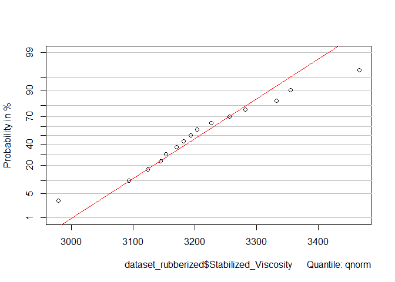

```r
library(e1071)
probplot(dataset_rubberized$Stabilized_Viscosity)
```

## Example 4.3.4: Inference on the Variance of a Normal Distribution

```r
#given variables
s = 117.61 #from data in Table 4.1
s_sqrd = s * s
degree_freedom = 14


#we'll use equation 4.39 to calculate the upper and lower bounds

#lower bound
lower_bound = degree_freedom*s_sqrd / qchisq(.975,degree_freedom)

#upper bound
upper_bound = degree_freedom*s_sqrd / qchisq(.025,degree_freedom)

paste("The interval is from ", round(sqrt(lower_bound),3), " to ", round(sqrt(upper_bound),3))
```

```
## [1] "The interval is from  86.105  to  185.483"
```

## Example 4.4: Rubberized Viscosity pt 2

Reconsider the stabilized viscosity data from Example 4.3. Find a 95% confidence interval on the mean stabilized viscosity.

```r
#given variables
null_hypothesis = 3200
dataset_rubberized = data.frame(Specimen = c(1:15), Stabilized_Viscosity = c(3193, 3124, 3153, 3145, 3093, 3466, 3355, 2979, 3182, 3227, 3256, 3332, 3204, 3282, 3170))

#mean and standard deviation
visc_mean = mean(dataset_rubberized$Stabilized_Viscosity)

visc_sd = sd(dataset_rubberized$Stabilized_Viscosity)

#t statistic
t_stat = (visc_mean - null_hypothesis) / (visc_sd / sqrt(nrow(dataset_rubberized)))

#Range
Range_t <- qt(c(.025, .975), df = 14)

#Lower bound
lower_bound = visc_mean - Range_t[2] * (visc_sd / sqrt(15)) #the brackets index the Range_t vector, giving us the second value

#Upper bound
upper_bound = visc_mean + Range_t[2] * (visc_sd / sqrt(15))

#Finished interval
print(paste(round(lower_bound,3), "< mean stabilized viscosity <", round(upper_bound, 3)))
```

```
## [1] "3145.602 < mean stabilized viscosity < 3275.864"
```

## Example 4.5: A Forging Process

A foundry produces steel forgings used in automobile manufacturing. We wish to test the hypothesis that the fraction conforming or fallout from this process is 10%. In a random sample of 250 forgings, 41 were found to be nonconforming.

What are your conclusions using a = 0.05?

```r
#given variables
errors = 41
sample_size = 250
null_hypothesis = .1

#Equation
Z = ((errors - .5) - sample_size * null_hypothesis) / sqrt(sample_size * null_hypothesis * (1 - null_hypothesis))

#an if statement only runs if the statement inside the parentheses
#for example
if(2>1){
  print("Go Gators")
}
```

```
## [1] "Go Gators"
```

```r
#prints Go Gators

#Let's use if statements to decide whether or not to accept the hypothesis
if(Z > 1.96) {
  print("REJECT")
}
```

```
## [1] "REJECT"
```

```r
if(Z < 1.96){
  print("ACCEPT")
}
```

## Example 4.6: Mortgage Applications

In a random sample of 80 home mortgage applications processed by an automated decision system, 15 of the applications were not approved. The point estimate of the fraction that was not approved is 15/80 = .1875.  
Assuming that the normal approximation to the binomial is appropriate, find a 95% confidence interval on the fraction of nonconforming mortgage applications in the process.

```r
#Given variables
total_samples = 80
rejected_applications = 15
fraction_rejected = rejected_applications / total_samples
Z_score = 1.96 #z is 1.96 for a 95% confidence interval

#Lower Bound
lower_bound = fraction_rejected - Z_score * sqrt((fraction_rejected * (1 - fraction_rejected)) / total_samples)

#Upper Bound
upper_bound = fraction_rejected + Z_score * sqrt((fraction_rejected * (1 - fraction_rejected)) / total_samples)

print(paste(round(lower_bound,4), "< p <", round(upper_bound, 4)))
```

```
## [1] "0.102 < p < 0.273"
```

## Example 4.7: Finding the Power of a Test

The mean contents of coffee cans filled on a particular production line are being studied. Standards specify that the mean contents must be 16.0 oz, and from past experience it is known that the standard deviation of the can contents is 0.1 oz. The null hypothesis is that mu = 16.0. A random sample of nine cans is to be used, and the type I error probability is specified as .05. Find the probability of type II error and the power of the test, if the true mean contents is 16.1 oz.

```r
#Given Variables
h0 = 16.1
h1 = 16.0
mean_difference = h0 - h1
standard_dev = .1
n = 9
z_desired = 1.96

#Find the beta, using equation 4.46
beta = pnorm((z_desired - (mean_difference * sqrt(n))/standard_dev)) - pnorm(-z_desired - (mean_difference * sqrt(n)/standard_dev))

power = 1 - beta
power
```

```
## [1] 0.8508304
```